# Презентация по лабораторной работе №1

Основы информационной безопасности

Сахно Н. В.

Российский университет дружбы народов, Москва, Россия

16 февраля 2024

# Информация

## Докладчик

- Сахно Н. В.
- студент группы НКАбд-04-23
- Российский университет дружбы народов

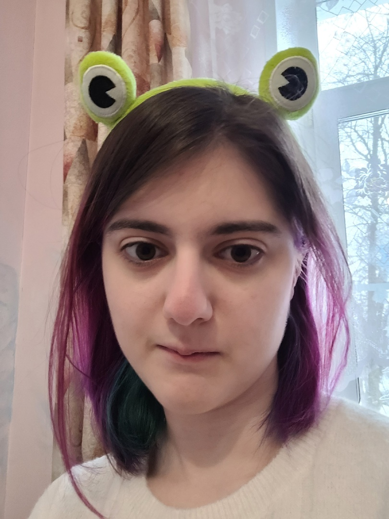

## Цель

Целью данной работы является приобретение практических навыков установки операционной системы на виртуальную машину, настройки ми- нимально необходимых для дальнейшей работы сервисов.

## Задание

1. Установка и настройка операционной системы.
2. Найти следующую информацию:
   1. Версия ядра Linux (Linux version).
   2. Частота процессора (Detected Mhz processor).
   3. Модель процессора (CPU0).
   4. Объем доступной оперативной памяти (Memory available).
   5. Тип обнаруженного гипервизора (Hypervisor detected).
   6. Тип файловой системы корневого раздела.

## Выполнение лабораторной работы

Я выполняю лабораторную работу на домашнем оборудовании, поэтому создаю новую виртуальную машину в VirtualBox, выбираю имя, местоположение и образ ISO, устанавливать будем операционную систему Rocku DVD

[figure not shown]

Окно создания виртуальной машины

## Соглашаюсь с проставленными настройками

[figure not shown]

Итоговые настройки

## Начинается загрузка операционной системы

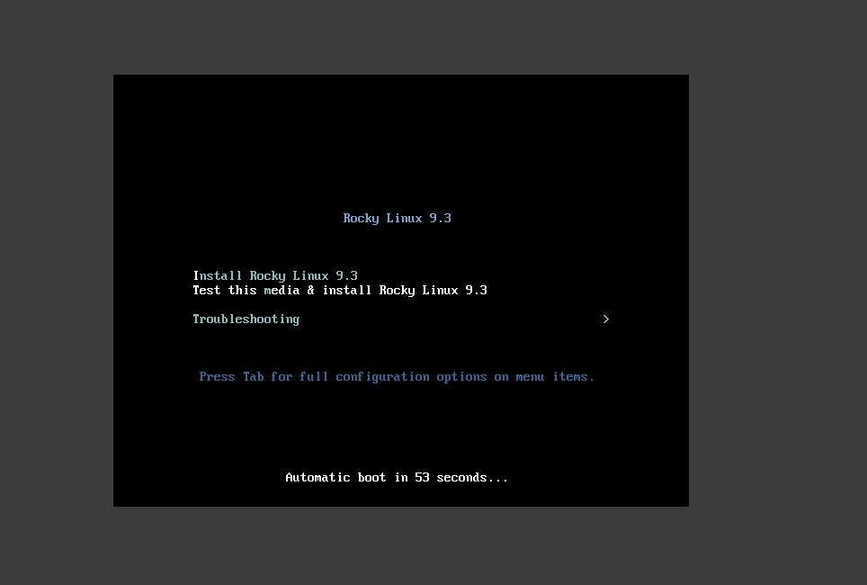

Загруза операционной системы Rocky

## При этом должен быть подключен в носителях образ диска!

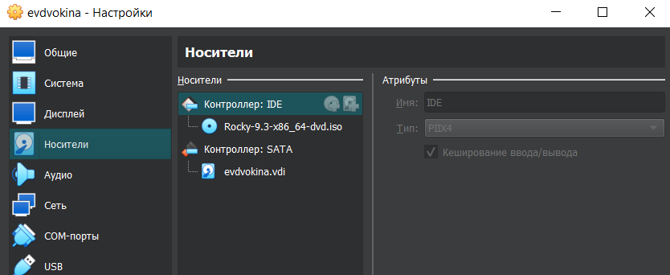

Подключенные носители

## Выбираю язык установки

[figure not shown]

Выбор языка установки

## В обзоре установки будем проверять все настройки и менять на нужные

[figure not shown]

Окно настроек

## Начало установки

[figure not shown]

Установка

## После заврешения установки образ диска сам пропадет из носителей

[figure not shown]

Проверка носителей

##После установки при запуске операционной системы появляется окно выбора пользователя

[figure not shown]

Окно входа в операционную систему

# Выполнение дополнительного задания

## 0

Открываю терминал, в нем прописываю dmesg | less

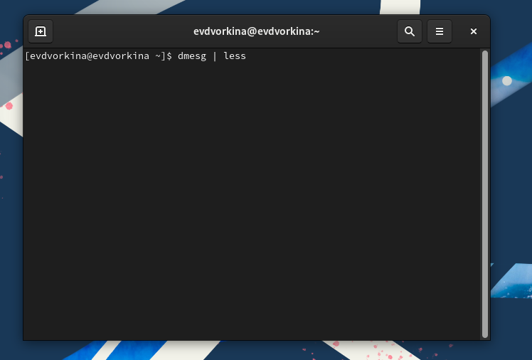

Окно терминала

## 1

Версия ядра 5.14.0-362.8.1.el9_3.x86_64

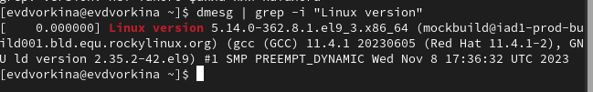

Версия ядра

## 2

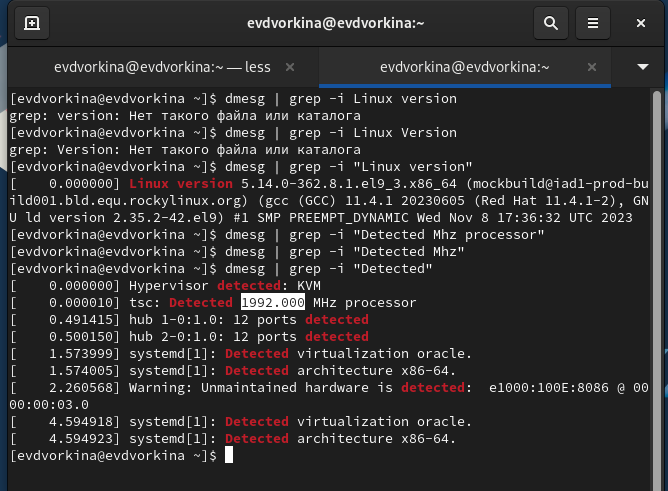

Частота процессора

## 3

Модель процессора Intel Core i7-8550U

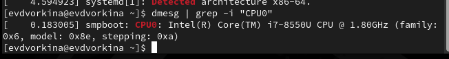

Модель процессора

## 4

Доступно 260860 Кб из 2096696 Кб

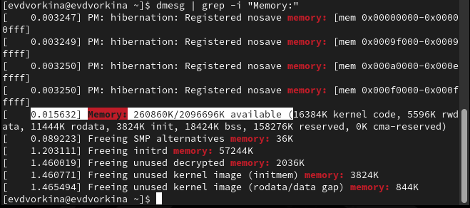

Объем доступной оперативной памяти

## 5

Обнаруженный гипервизор типа KVM

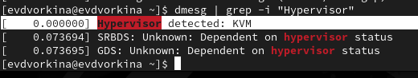

Тип обнаруженного гипервизора

## 6

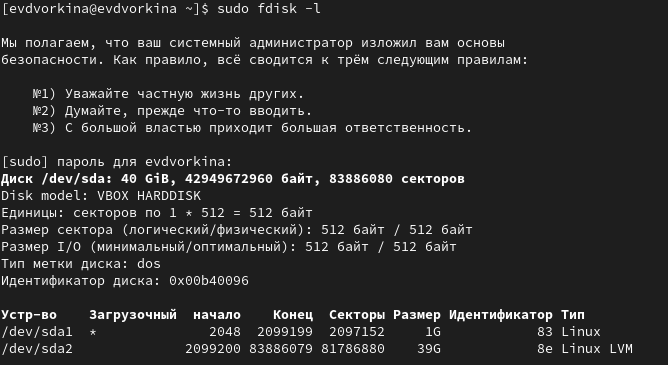

Тип файловой системы

## 7

Далее показана последовательно монтирования файловых систем

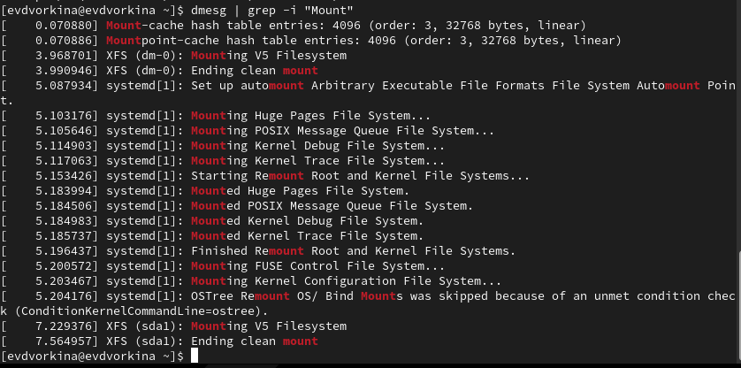

Последовательность монтирования файловых систем

## Вывод

Я приобрела практические навыки установки операционной системы на виртуальную машину, настройки ми- нимально необходимых для дальнейшей работы сервисов.

[output not shown]